# Statistics some problems (and solution)

Tomasz Przechlewski

March, 2019

# Poor definitions: Full Time Equivalence (FTE)

Number of students.

**Who is a student?**

Student is a person attending to a 3rd level status school in in the 3-stage education system (cf Educational_stage). The answer is still non-obvious as there are many forms of tertiary education. For example:

The UNESCO stated that tertiary education focuses on learning endeavors in specialized fields. It includes academic and higher vocational education.

So according to the above definition the school do not belongs to tertiary education if its status is not academic and/or higher vocational. Example: Dance Academy or University for Elderly people (aka University of the 3rd Age). Both are popular in Poland.

In many countries there are some certification scheme. For example in Poland a school must apply (and get) a certificate to be regarded as high school (ie part of tertiary level of education)

**Heads vs Majors**

Student can be enrolled to more than one course (major). So for counting heads it is necessary to remove duplicates otherwise one would count majors not persons.

**Part time studies**

FTE stands for Full-Time-Equivalent, an approximation of the number of students who would be enrolled full-time

Full time equivalent (FTE) – FTE is based on student credit hours. It is obtained by dividing student credit hours by some a number of credit hours for full-time-study.

Conclusion: Majors, Persons or FTEs? Which is the best?

[University of Utah/Office of Analysis, Assessment and Accreditation](http://www.usu.edu/aaa/about_our_data.cfm) google:single multiple majors fte

# Measurement of tourism activity

**Who is a tourist**. According to Glossary:Tourism

Tourism means the activity of visitors taking a trip to a main destination outside their usual environment, for less than a year, for any main purpose, including business, leisure or other personal purpose, other than to be employed by a resident entity in the place visited.

According to the above definition to be regarded as tourist one has to change her/his accommodation place for less than one year (otherwise Eurostat would regard her/him as migrant)

The usual meaning (at least in Poland) is that tourist is travelling for leisure not to work. People travelling to work has other needs/aims than those travelling to rest (they usually do not use hotels for example) so the above definition solves some problems but at the same time creates many others.

Number of tourists: do not distinguish between various form of tourists, difficult to collect (who is a tourist anyway?)

# Concept of an indicator

Various `number of’ tourist-oriented establishments (hotels, catering units, beds, nights spent) etc. They do not measure tourists per-se but are highly related and more reliable (as easier to count).

Indicator of tourist activity (by various tourist types).

Conclusion: measurement of tourism activity is not trivial Other similar: internet user, migrant, unemployed person, illiterate person

NACE = Statistical Classification of Economic Activities = the industry standard classification system used in the European Union. NACE uses four hierarchical levels: SectionDivision.Group.Class, where Section is denoted by a single letter. Examples:

- **A01.44** A = Agriculture, forestry and fishing (section); 01 = Crop and animal production, hunting and related service activities (division); 01.4 = Animal production (group); 01.44 = raising of camels and camelids (section)
- **I55.1** Accommodation and food service activities (I); Accommodation (55); Hotels and similar accommodation (55.1)

# Sloppy measurement: measurement of tourism activity

Two sides of tourism: supply side (hotels) / demand side (tourists)

BTW: demand = how much a product/service is desired; supply = how much the market can offer

Tourism supply statistics (accommodation statistics): Data on rented accommodation ie. capacity and occupancy of tourist accommodation establishments in the reporting country. How collected? Registers?

**How statistical data is collected?**: exhaustive data vs sample. **Exhaustive**: dedicated sureys (obligatory reports) vs administrative registers (births, deaths, police statistics). Sample: representative sample vs random sample vs panel data. Panels (cf [Panel Research](https://www.questionpro.com/blog/panel-research-why-it-matters/)). Panels are overused nowadys (cf https://panelariadna.pl/):

Quirks of data collection: Data up to year 2015 inclusive refer to only those units that made the statistical reports. Starting of data for January 2016, the method of imputation data was implemented (ie replacing missing data with some (possibly meaningful :-)) values. (cf [BDL](https://bdl.stat.gov.pl/BDL/dane/podgrup/temat/18/240/2396))

Impu-what? Missing data problem

[figure not shown]

**Tourism demand statistics**: Data on participation in tourism of the residents of the reporting country. How collected? Surveys?

Most of the time, data on domestic and outbound trips (where “outbound tourism” means residents of a country travelling in another country) is collected via sample surveys (cf [Annual data on trips of EU residents](https://ec.europa.eu/eurostat/cache/metadata/en/tour_dem_esms.htm) and Tourism_statistics_-_top_destinations)

Regulations concerning data collection in tourism (hundreds of pages): Glossary:Supply_side_tourism_statistics and [EU regulation No 692/2011](https://eur-lex.europa.eu/legal-content/EN/ALL/?uri=CELEX:32011R0692)

So now we know what we are dealing with…

# Poor definitions: dreadful aggregates

Indicators can be divided to hard indicators and soft indicators. *Hard indicators* denote hard facts while soft indicators are *beliefs* and *intentions*. For example number of hotels is a fact, while intention to stay abroad less than a year is not a fact but an intention. In Poland at least 80% respondents declares they intend to vote, while the true turnover never exceed 55%. In other words measuring something using soft indicators is prone to (significant) errors.

That not means that hard indicator is error-free. By definition it measures not the phenomenon but some proxy associated with the phenomenon.

With hard indicator we have precise measurement of imprecise measure. With soft indicator we have imprecise measurement of imprecise measure.

To cure (or hide) the problems aggregates of indicators are constructed, eiter as sums (*indexes* or *formative*) or as averages (factors or *reflective*. Indexes are more popular in economics while averages/factors are more popular in psychology, sociology etc…

For example Gross National Product (GDP) is an index while (customer) satisfaction defined as some set of opinions on a product would be a factor.

Control question: what is measured with GDP?

Collection methods from most to last reliable:

- administrative registers (almost all)
- some obligatory reports, some sample-based
- panels, obligatory reports when respondent is unable/unwill/ to provide information or take part at all), most sample-based (intensions, soft factors)

Typical collection method description of a sample based survey: Data collected from 1st April to 2nd April 2019. Cross national panel (or sample). Respondent age +18. Panel size 1020. Quotas representative for sex, age and residence type

No information provided on non-response rate/non-contact rate (why?).

**Example**: How to measure illiteracy? A. Ask a straight question (can you read/write). B. Ask a question how many books respondent read last year, if zero = illiterate (nasty!). C. Ask for certificate (infeasable). I wonder about illiteracy rate of many countries if approach B would be excercised:-)

# What, when and where

No doubt in every reliable survey the population has to be precisely defined ie 3 dimensions of every surveyed unit should be fixed: definition (**what**), time (**when** measured), space (*where*)…

I always repet to my students: if you look at some data (in the media for example), start from establishing if you know **what**, **when** and **where**. If no information (or *reliable link*–called source–to information) is provided on any of the fixed dimensions of data, treat this data as rubbish and do not waste time to use/analyse it.

Further dissemination of such defective data should be subjected to publicly prosecuted (joke)

I tried to show you already that **what** is complicated and often highly unreliable/arbitrary (the nature of the phenomenon or/and measurement difficulties).

**When** dimension is much more simpler due to universal standard, ie. time. You gather data or for a certain moment (how many hotels are in use in 31st December 2018) or for certain period of time (how many beds were sold in these hotels in 3rd quarter of 2018).

**Where** dimensions in turn is usually based on administrative or statistical (geographical) units (country, state/province, county, community). But contrary to time dimension there is no universal or globally-accepted standard for **geostatistical** units. Usually such a standard is based on administrative system which is country-dependent.

EU regulates everything, statistics included.

Conclusion: The pigs had to expend enormous labours every day upon mysterious things called “files,” “reports,” “minutes,” and “memoranda.” These were large sheets of paper which had to be closely covered with writing, and as soon as they were so covered, they were burnt in the furnace (George Orwell, Animal Farm)

# NUTS and TERYT

The Nomenclature of Territorial Units for Statistics (NUTS) is a geocode standard for referencing the subdivisions of countries for statistical purposes. The standard is developed and regulated by the European Union, and thus only covers the member states of the EU in detail (cf [NUTS](https://en.wikipedia.org/wiki/Nomenclature_of_Territorial_Units_for_Statistics))

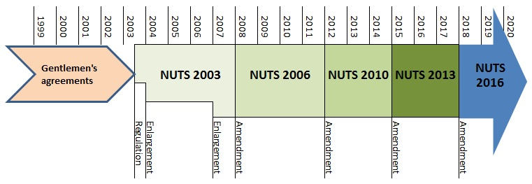

NUTS1 (level) – macroregion, NUTS2 – state, NUTS3 – subregion (several counties in case of Poland)

NUTS1 level is only for statistical purposes (but regions are in fact distinct due to history, economics, natural-conditions, cultural factors etc… )

There is a relevant and interesting page by GUS (Main Statistical Office or Główny Urząd Statystyczny), but unfortunately in Polish (use google translate :-) in case you are interested or mail me) (cf [Klasyfikacja NUTS w Polsce](https://stat.gov.pl/statystyka-regionalna/jednostki-terytorialne/klasyfikacja-nuts/klasyfikacja-nuts-w-polsce/) )

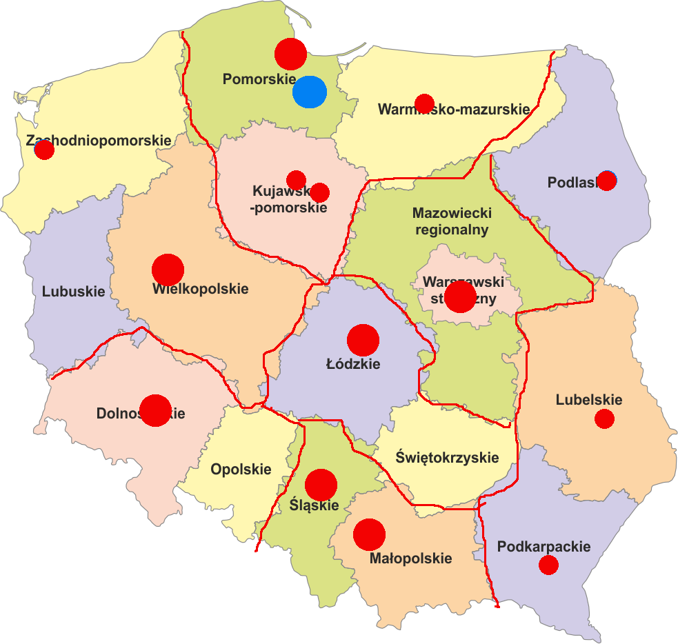

A Polish county (called “powiat”) is 2-nd level administrative unit.

In ancient Poland powiat was called “starostwo” and the head of a “starostwo was called”starosta“.”Stary" means Old, so “starosta” is an old (and thus wise) person. BTW the head of powiat is “starosta” as 600 years ago:-)

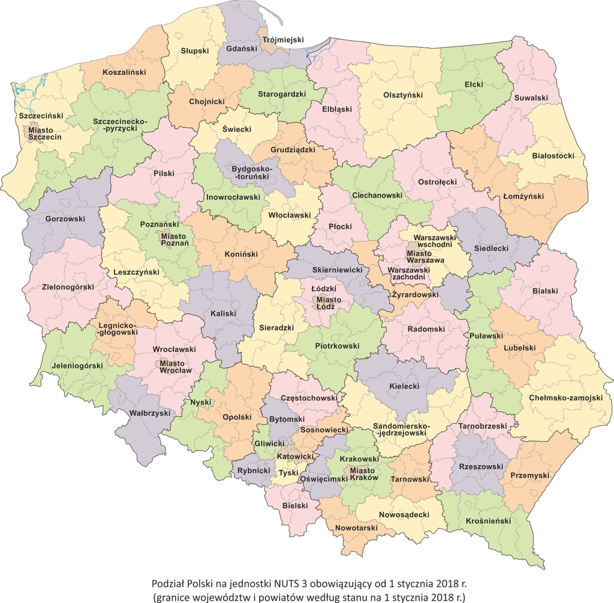

The 3rd level administrative unit is called “gmina” (community).

There are (approximately) 380 counties and 2750 communities in Poland.

As Poland population is 38,5 mln and the area equals 312,7 sq kilometers (120 persons per 1 sqkm) on the average each powiat has 820 sqkm and each community has 113.5 sqkm or approximately 100 thousand persons per “powiat and 14 thousand per”gmina".

**TERYT** is a Polish NUTS (developed some 50 years ago). It is complex system which includes identification of administrative units. Every unit has (up to) a 7-digit id number: wwppggt where ww = “województwo” id, pp = “powiat” id, gg = “gmina” id and “t” decodes type-of-community (rural, municipal or mixed). Higher units has trailing zeros for irrelevant part of id, so 14 or 1400000 means the same; as well as 1205 and 1205000. Six numbers is enough to identify a community (approx 2750 units).

So you are now experts on administrative division of Poland.